# Data Visualization: Assignment 1

Ethan Yee (ty2247)

# Loading data and packages

First, load the required packages and the .csv file.

```r
require(ggplot2)
require(grid)
require(scales)
# Read raw data
data.raw <- read.csv("C:/Users/user/Desktop/Rstuff/WORKING DIRECTORY/Microbe-scope-bugs.csv")
```

# Pre-processing

```r
# assign descriptive column names where absent
names(data.raw)[1]<-"germ"

# remove non-needed columns
data.trunc <- data.raw[-1,c(1,2,4:7,9:11)]
## Alternatively, use notes <- grep(pattern="note", x=names(data.trunc), ignore.case=TRUE)
##names(data.trunc)[notes] # double check we got the right columns
##data.trunc <- subset(data.trunc, select = -notes) # apply filter.

# function to remove percent signs
dropPct<-function(df, var){
  dropPct<-strsplit(as.character(df[[var]]), split="%")
  df[[var]]<-as.numeric(dropPct)
  return(df[[var]])
}

# remove % signs from 2nd col, leaving a numeric value.
data.trunc[["case.fatality.rate"]]<-dropPct(data.trunc, "case.fatality.rate")
```

# Check for missing data

```r
# coerce 3rd col into numeric form
data.trunc$average.basic.reproductive.rate <- as.numeric(as.character(data.trunc$average.basic.reproductive.rate))
##Alternatively, use as.numeric(levels(data.trunc$average.basic.reproductive.rate))[data.trunc$average.basic.reproductive.rate]
## (see http://stackoverflow.com/questions/3418128/how-to-convert-a-factor-to-an-integer-numeric-without-a-loss-of-information )

# check for missing data in our 2 numeric columns of interest
c("Missing values for case fatality rate: ", sum(is.na(data.trunc$case.fatality.rate)))
```

```
## [1] "Missing values for case fatality rate: "
## [2] "0"
```

```r
c("Missing values for reproductive rate: ", sum(is.na(data.trunc$average.basic.reproductive.rate)))
```

```
## [1] "Missing values for reproductive rate: "
## [2] "1"
```

```r
# average.basic.reproductive.rate has one NA value. find it
which(is.na(data.trunc$average.basic.reproductive.rate))
```

```
## [1] 1
```

```r
# the primary mode of transmission column is a factor. looking at the data, there are missing values that are just blanks
str(data.trunc$primary.mode.of.transmission)
```

```
##  Factor w/ 9 levels "","airborne",..: 1 3 4 6 7 3 1 4 5 6 ...
```

```r
# get the number and location of missing data in 3rd column
sum((as.character(data.trunc$primary.mode.of.transmission))=="")
```

```
## [1] 2
```

```r
which((as.character(data.trunc$primary.mode.of.transmission))=="")
```

```
## [1] 1 7
```

As it turns out, the row with an `NA` value for `average.basic.reproductive.rate` also has missing data for the 3rd column. So rows 1 and 7 are the problem data

# Checking for problematic data

Now check the case fatality rate and average basic reproductive rate to see if there is problematic data.

Firstly, `case.fatality.rate` is a percentage, so check to see if there are any obvious errors.

```r
c( min(data.trunc$case.fatality.rate), max(data.trunc$case.fatality.rate) )
```

```
## [1]   0 100
```

Seems fine, so we move on to average basic reproductive rate.

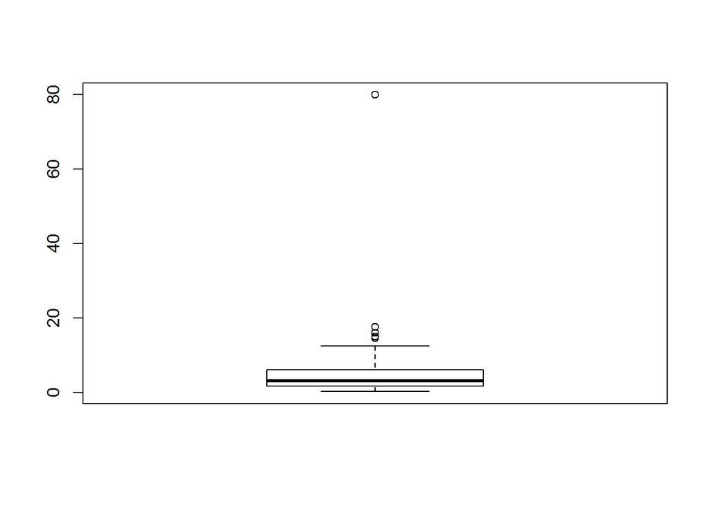

```r
#preliminary visualization of average.basic.reproductive.rate
boxplot(data.trunc$average.basic.reproductive.rate)
```

```r
#seems like there's an outlier, find the row of interest
which((data.trunc$average.basic.reproductive.rate)>=70)
```

```
## [1] 17
```

Now, we can look at all the problematic rows and decide what to do with them.

```r
#view the offending rows
data.trunc[c(1, 7, 17), ]
```

```
##                       germ case.fatality.rate
## 2      Anthrax (untreated)              20.00
## 8                  Cholera               1.63
## 18 Malaria (P. falciparum)               0.50
##    average.basic.reproductive.rate primary.mode.of.transmission
## 2                               NA
## 8                             2.13
## 18                           80.00                        bites
##    survival.time.on.surfaces
## 2
## 8
## 18                         0
##    survival.in.ideal.conditions..ie..blood..faeces. pathogen.type
## 2                                                       bacterium
## 8                                                       bacterium
## 18                                                ~      parasite
##    infectious.dose viral.load.in.acute.stage
## 2          100,000
## 8        1,000,000
## 18         1 to 10
```

```r
# We are missing important data for anthrax, and the malaria data seems unusual. Omit those rows.
data.trunc <- data.trunc[-c(1,17), ]
# We can google transmission info for cholera. WHO says it's food/water, so let's put it in food category.
# check to see if we have the right column
data.trunc$germ[6]
```

```
## [1] Cholera
## 41 Levels: Anthrax (untreated) ... Typhoid
```

```r
data.trunc$primary.mode.of.transmission[6] <- "food"
```

# Futher data cleaning

Look at the transmission categories again.

```r
table(data.trunc$primary.mode.of.transmission)
```

```
##
##                          airborne airborne droplet            bites
##                0                1               14                6
##      body fluids       fecal-oral             food   sexual contact
##                4                5                3                3
##         surfaces
##                2
```

It seems like airborne and airborne droplets should be the same category. Since there is only one entry for airborne, we can find that row and change it.

```r
which((data.trunc$primary.mode.of.transmission)== "airborne")
```

```
## [1] 17
```

```r
data.trunc$primary.mode.of.transmission[17] <- "airborne droplet"
```

If we use the table() function on this column again, we find that “airborne” has not completely gone away. We forgot to coerce the column from factor to characters.

```r
data.trunc$primary.mode.of.transmission <- as.character(data.trunc$primary.mode.of.transmission)
table(data.trunc$primary.mode.of.transmission)
```

```
##
## airborne droplet            bites      body fluids       fecal-oral
##               15                6                4                5
##             food   sexual contact         surfaces
##                3                3                2
```

# Saving the data

Now that we have clean data, save it.

```r
save(data.trunc, file = "Microbes_cleaned.Rdata")
load("Microbes_cleaned.Rdata")
```

# Drawing the graph

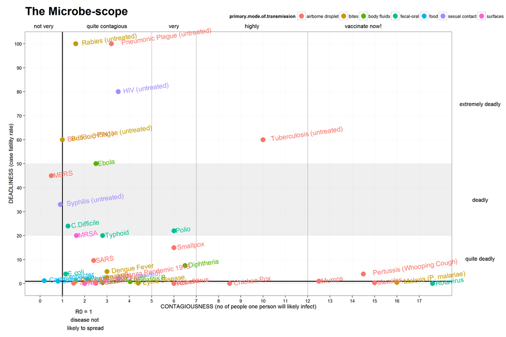

```r
p<- ggplot(data.trunc, aes(x=average.basic.reproductive.rate, y=case.fatality.rate, colour=primary.mode.of.transmission)) +
  geom_vline(xintercept = 1, colour="black", size=1) +
  geom_vline(xintercept = c(5,7,12), colour="grey", size=1, alpha=.5) +
  geom_hline(yintercept = 1, colour="black", size=1) +
  annotate("rect", xmin=-Inf, xmax=Inf, ymin=0, ymax=1, fill="grey40", alpha=0.1) +
  annotate("rect", xmin=-Inf, xmax=Inf, ymin=20, ymax=50, fill="grey40", alpha=0.1) +
  geom_point(size = 5) +
  geom_text(aes(label = germ), hjust=-.11, vjust=.5, angle=8) +
  scale_y_continuous(name="DEADLINESS (case fatility rate)", limit=c(0, 100), breaks= seq(0,100,10), minor_breaks=NULL) +
  scale_x_continuous(name="CONTAGIOUSNESS (no of people one person will likely infect)", breaks= seq(0,17,1), minor_breaks=NULL) +
  labs(title="The Microbe-scope") +
  theme_bw() +
  theme(panel.grid.major = element_line(colour="grey", linetype = "dotted"), plot.margin = unit(c(3,8,4,1), "lines"), legend.direction = "horizontal", legend.position = c(.8,1.06), plot.title= element_text(size=24, face="bold", vjust=5, hjust=0))

#replicate the annotations
p1<- p + annotation_custom(grob=textGrob(label="not very"), xmax=1, ymin=110) +
  annotation_custom(grob=textGrob(label="quite contagious"), xmin=1, xmax=5, ymin=110) +
  annotation_custom(grob=textGrob(label="very"), xmin=5, xmax=7, ymin=110) +
  annotation_custom(grob=textGrob(label="highly"), xmin=7, xmax=12, ymin=110) +
  annotation_custom(grob=textGrob(label="vaccinate now!"), xmin=12, xmax=17, ymin=110) +
  annotation_custom(grob=textGrob(label="extremely deadly"), xmin=21, ymin=50, ymax=100) +
  annotation_custom(grob=textGrob(label="deadly"), xmin=21, ymin=20, ymax=50) +
  annotation_custom(grob=textGrob(label="quite deadly"), xmin=21, ymin=1, ymax=20) +
  annotation_custom(grob=textGrob(label="R0 = 1 \n disease not \n likely to spread"), xmin=1, xmax=3, ymax=-25)

#remove clipping so data labels and the words outside the graph area will show
gt <- ggplot_gtable(ggplot_build(p1))
gt$layout$clip[gt$layout$name=="panel"] <- "off"
grid.draw(gt)
```

# Log transform?

If we want to, we can do a log transform using the following code:

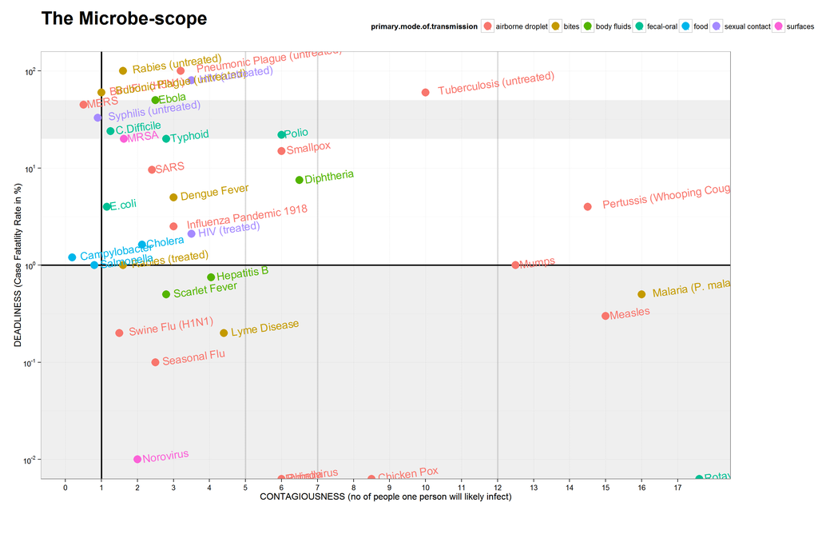

```r
p1 + scale_y_log10("DEADLINESS (Case Fatatlity Rate in %)", breaks = trans_breaks("log10", function(x) 10^x), labels = trans_format("log10", math_format(10^.x)))
```

============================